## Material Suplementario

El trabajo se basa en los datos de Chip-seq obtenidos en el artículo ChIP-seq reveals the global regulator AlgR mediating cyclic di-GMP synthesis in Pseudomonas aeruginosa.

Detección de motivos

Se obtienen las secuencias en formato .txt de GEO Accesion GSE65356 (http://www.ncbi.nlm.nih.gov/geo/query/acc.cgi?acc=GSE65356), se convierten al formato .bed requerido para el análisis, mediante:

En bash: more secuencia_DirectaDeGeo.txt | grep -v “#” | cut -f 2,3,10 > seqid.bed

Usando R:  
table <- read.table(“../Downloads/seqid.bed”) Chrname <- rep(“Chromosome”,length(table[,1])) ntable <- data.frame(Chrname,table) write.table(ntable,“../Downloads/seqid_clean.bed”, sep = “”, row.names = F, col.names =F, quote = F)

En RSat, se cambia a la base de datos de procariotes; en sequence tools -> sequences from bed/gff/vcf y se elige el organismo Pseudomonas aeruginosa pao1.ASM676v1.30; la opción Mask repeats se deja en su forma predeterminada. Tras obtener los archivos en formato .fasta, se procede a usar la herramienta Peak motifs; con los parámetros default excepto en Compare discovered motifs with databases, en la que únicamente se elige a los procariotes en RegulonDB.

Análisis de Peak Calling

Tabla 3: Resultados de matrix-clustering para ambos casos.

Peak Name Input motifs Clusters found Thresholds 2588 42 10 10 2 (8,2) 4(2,5,2,1) Ncor = 0.4 cor = 0.6 algr 43 10 10 5(6,1,1,1,1) 6(4,2,1,1,1,1) Ncor = 0.4 cor = 0.6 exsa 44 5 10 2(4,1) 8(2,2,1,1,1,1,1,1) Ncor = 0.4 cor = 0.6 gaca 45 10 10 3(4,4,2) 5(2,2,3,2,1) Ncor = 0.4 cor = 0.6 mext 46 10 10 6(2,3,1,1,2,1) 8(2,2,1,1,1,1,1,1) Ncor = 0.4 cor = 0.6 mvfr 47 10 10 4(6,2,1,1) 7(2,2,2,1,1,1,1) Ncor = 0.4 cor = 0.6 rpon 48 10 10 4(4,3,2,1) 4(4,3,1,1,1) Ncor = 0.4 cor = 0.6 soxr 49 10 10 5(2,2,4,1,1) 6(2,2,2,2,1,1) Ncor = 0.4 cor = 0.6 vfr 50 10 10 5(4,2,2,1,1) 5(4,2,2,1,1) Ncor = 0.4 cor = 0.6 wspr 51 6 10 5(2,1,1,1,1) 5(3,3,2,1,1) Ncor = 0.4 cor = 0.6

Control Negativo

5308832 reads; of these: 5308832 (100.00%) were unpaired; of these: 3284383 (61.87%) aligned 0 times 1983911 (37.37%) aligned exactly 1 time 40538 (0.76%) aligned >1 times 38.13% overall alignment rate SRR1776544 bowtie2 PAO1 Downloads/fastq/SRR1776544.fastq -S SAM/SRR1776544.sam

5420068 reads; of these: 5420068 (100.00%) were unpaired; of these: 2913278 (53.75%) aligned 0 times 2459292 (45.37%) aligned exactly 1 time 47498 (0.88%) aligned >1 times 46.25% overall alignment rate SRR1776545 bowtie2 PAO1 Downloads/fastq/SRR1776545.fastq -S SAM/SRR1776545.sam

6036968 reads; of these: 6036968 (100.00%) were unpaired; of these: 3514824 (58.22%) aligned 0 times 2474726 (40.99%) aligned exactly 1 time 47418 (0.79%) aligned >1 times 41.78% overall alignment rate SRR1776546 bowtie2 PAO1 Downloads/fastq/SRR1776546.fastq -S SAM/SRR1776546.sam -D 20 -R 3 -N 0 -L 20 -i S,1,0.50

5161454 reads; of these: 5161454 (100.00%) were unpaired; of these: 2239403 (43.39%) aligned 0 times 2871495 (55.63%) aligned exactly 1 time 50556 (0.98%) aligned >1 times 56.61% overall alignment rate SRR1776547 bowtie2 PAO1 Downloads/fastq/SRR1776547.fastq -S SAM/SRR1776547.sam -D 20 -R 3 -N 0 -L 20 -i S,1,0.50

4620331 reads; of these: 4620331 (100.00%) were unpaired; of these: 1898380 (41.09%) aligned 0 times 2678292 (57.97%) aligned exactly 1 time 43659 (0.94%) aligned >1 times 58.91% overall alignment rate SRR1776548 bowtie2 PAO1 Downloads/fastq/SRR1776548.fastq -S SAM/SRR1776548.sam -D 20 -R 3 -N 0 -L 20 -i S,1,0.50

5019633 reads; of these: 5019633 (100.00%) were unpaired; of these: 1142783 (22.77%) aligned 0 times 3808400 (75.87%) aligned exactly 1 time 68450 (1.36%) aligned >1 times 77.23% overall alignment rate SRR1776549 bowtie2 PAO1 Downloads/fastq/SRR1776549.fastq -S SAM/SRR1776549.sam -D 20 -R 3 -N 0 -L 20 -i S,1,0.50

4838667 reads; of these: 4838667 (100.00%) were unpaired; of these: 823979 (17.03%) aligned 0 times 3944953 (81.53%) aligned exactly 1 time 69735 (1.44%) aligned >1 times 82.97% overall alignment rate SRR1776550 bowtie2 PAO1 Downloads/fastq/SRR1776550.fastq -S SAM/SRR1776550.sam -D 20 -R 3 -N 0 -L 20 -i S,1,0.50

7908293 reads; of these: 7908293 (100.00%) were unpaired; of these: 2560348 (32.38%) aligned 0 times 5241027 (66.27%) aligned exactly 1 time 106918 (1.35%) aligned >1 times 67.62% overall alignment rate SRR1776551 bowtie2 PAO1 Downloads/fastq/SRR1776551.fastq -S SAM/SRR1776551.sam -D 20 -R 3 -N 0 -L 20 -i S,1,0.50

4824339 reads; of these: 4824339 (100.00%) were unpaired; of these: 852513 (17.67%) aligned 0 times 3892440 (80.68%) aligned exactly 1 time 79386 (1.65%) aligned >1 times 82.33% overall alignment rate

MACS2 Peak Call macs2 callpeak -t SAM/$bname.sam -f SAM -n peaks/$bname -g 6.3e6 -q 0.01 –nomodel –shiftsize 100

Comandos en el servidor:

Peak Calling: $RSAT/perl-scripts/peak-motifs -v 1 -title ‘2688vsmacs2’ -i $RSAT/public_html/tmp/apache/2016/02/20/peak-motifs.2016-02-20.195401_2016-02-20.195401_PP1XpT/peak-motifspeak_seq -max_seq_len 1000 -markov auto -disco oligos,positions -nmotifs 5 -minol 6 -maxol 7 -no_merge_lengths -2str -origin center -motif_db regulonDB tf $RSAT/public_html/motif_databases/REGULONDB/regulonDB_2015-08-07.tf -scan_markov 1 -source getfasta -task purge,seqlen,composition,disco,merge_motifs,split_motifs,motifs_vs_motifs,timelog,archive,synthesis,small_summary,motifs_vs_db,scan -prefix peak-motifs -noov -img_format png -outdir $RSAT/public_html/tmp/apache/2016/02/20/peak-motifs.2016-02-20.195401_2016-02-20.195401_PP1XpT)

Matrix-clustering: $RSAT/perl-scripts/matrix-clustering -v 1 -max_matrices 300 -matrix_format transfac -i $RSAT/public_html/tmp/www-data/2016/02/22/matrix-clustering_2016-02-22.014846_eMBEdG/matrix-clustering_query_matrices.transfac -hclust_method average -title ‘testfun2588’ -metric_build_tree ‘Ncor’ -lth w 5 -lth cor 0.6 -lth Ncor 0.4 -quick -label_in_tree name -return json,heatmap -o $RSAT/public_html/tmp/www-data/2016/02/22/matrix-clustering_2016-02-22.014846_eMBEdG/matrix-clustering 2> $RSAT/public_html/tmp/www-data/2016/02/22/matrix-clustering_2016-02-22.014846_eMBEdG/matrix-clustering_err.txt

Control negativo: $RSAT/perl-scripts/random-genome-fragments -template_format len -i $RSAT/public_html/tmp/apache/2016/02/21/random-genome-fragments_2016-02-21.202329_U9mlWz.lengths -org Pseudomonas_aeruginosa_pao1.ASM676v1.30 -return seq -rm -o $RSAT/public_html/tmp/apache/2016/02/21/random-genome-fragments_2016-02-21.202329_U9mlWz_fragments.fasta 2> $RSAT/public_html/tmp/apache/2016/02/21/random-genome-fragments_2016-02-21.202329_U9mlWz_error_log.txt

$RSAT/perl-scripts/peak-motifs -v 1 -title ‘2588_negativectrol’ -i $RSAT/public_html/tmp/www-data/2016/02/22/peak-motifs.2016-02-22.032359_2016-02-22.032359_flPJWK/peak-motifspeak_seq -ctrl $RSAT/public_html/tmp/www-data/2016/02/22/peak-motifs.2016-02-22.032359_2016-02-22.032359_flPJWK/peak-motifscontrol_seq -max_seq_len 1000 -markov auto -disco oligos,positions -nmotifs 5 -minol 6 -maxol 7 -no_merge_lengths -2str -origin center -motif_db regulonDB tf $RSAT/public_html/motif_databases/REGULONDB/regulonDB_2015-08-07.tf -scan_markov 1 -task purge,seqlen,composition,disco,merge_motifs,split_motifs,motifs_vs_motifs,timelog,archive,synthesis,small_summary,motifs_vs_db,scan -prefix peak-motifs -noov -img_format png -outdir $RSAT/public_html/tmp/www-data/2016/02/22/peak-motifs.2016-02-22.032359_2016-02-22.032359_flPJWK

Bibliografía. http://nar.oxfordjournals.org/content/43/17/8268.long Langmead, B., Trapnell, C., Pop, M., & Salzberg, S. L. (2009). Ultrafast and memory-efficient alignment of short DNA sequences to the human genome. Genome biol, 10(3), R25.

## Peak Calling Statistics

Llamamos datos

```r
chip_art <- read.table("~/Downloads/GSE65356_algrmacs2e15_peaks.txt", header = T)
chip_ours <-read.table("~/JvH_Practice/peaks2/SRR1776549_peaks.xls", header=T)
```

Ploteamos la distribución de reads de acuerdo al pileup.

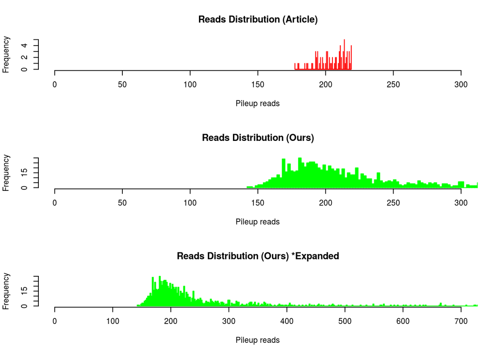

```r
par(mfrow=c(3,1))
hist(chip_art$pileup,
     main="Reads Distribution (Article)",
     ylab="Frequency",
     xlab="Pileup reads",
     xlim = c(0,300),
     col="red",
     border = "red",
     breaks = 500)

hist(chip_ours$pileup,
     main="Reads Distribution (Ours)",
     ylab="Frequency",
     xlab="Pileup reads",
     xlim = c(0,300),
     col="green",
     border = "green",
     breaks = 500)

hist(chip_ours$pileup,
     main="Reads Distribution (Ours) *Expanded",
     ylab="Frequency",
     xlab="Pileup reads",
     xlim = c(0,700),
     col="green",
     border = "green",
     breaks = 500)
```

Ploteamos el enriquecimiento de picos uno sobre otro y viceversa, para ver dónde coinciden y con cuánta precisión.

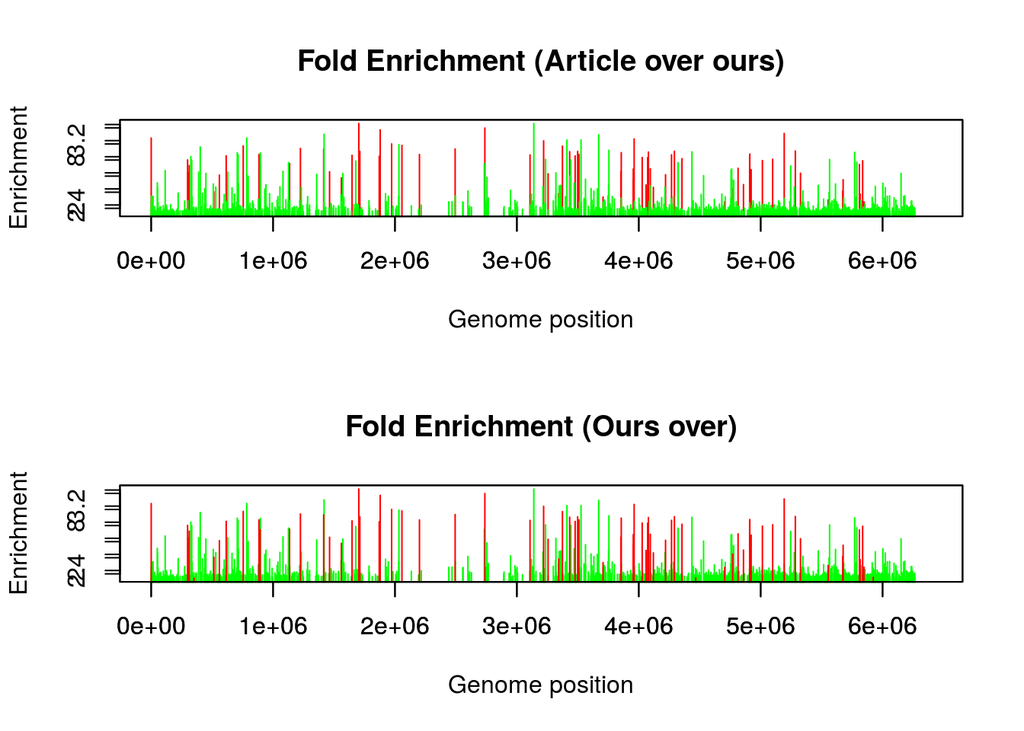

```r
par(mfrow=c(2,1))
plot(chip_art  $abs_summit,chip_art$fold_enrichment,
     main="Fold Enrichment (Article over ours)",
     ylab="Enrichment",
     xlab="Genome position",
     xlim = c(0,6400000),
     col="red",  type = "h")

par(new=T)

plot(chip_ours$abs_summit,
     chip_ours$fold_enrichment,
     xlim = c(0,6400000),
     ylab = "",
     xlab = "",
     col="green", type = "h")


plot(chip_ours $abs_summit,chip_ours$fold_enrichment,
     main="Fold Enrichment (Ours over)",
     ylab="Enrichment",
     xlab="Genome position",
     xlim = c(0,6400000),
     col="green",  type = "h")

par(new=T)

plot(chip_art$abs_summit,
     chip_art$fold_enrichment,
     xlim = c(0,6400000),
     ylab = "",
     xlab = "",
     col="red", type = "h")
```